# Supplementary material

## Model numbering and interpretation

Model numbers match the manuscript throughout:

- **Model 1:** occupational homogamy, predicted by gender, research area, their interaction and baseline covariates (age, age similarity and relationship duration).
- **Model 2:** meeting-context category distributions, using the same predictors.
- **Model 3:** relationship-formation timing category distributions, using the same predictors.
- **Model 4:** Model 1 with meeting context added.
- **Model 5:** Model 1 with relationship-formation timing added.
- **Models 6 and 7:** indirect-association calculations for meeting context and formation timing, respectively.

Probability contrasts are expressed in percentage points; standardized coefficients, odds ratios and other statistics are labelled separately. Confidence intervals are pointwise unless otherwise stated, and each table identifies the adjustment used for p-values.

**The 15 comparisons in Table S3:** all unique pairs among men and women in Humanities & Social Sciences, Life Sciences, and Natural & Engineering Sciences (six groups). These comprise three women–men comparisons within areas, six area comparisons within genders, and six comparisons differing in both gender and area. They compare Model 1 adjusted probabilities of occupational homogamy, with the first named group minus the second. P-values are Tukey-adjusted across all 15 comparisons. These pairwise comparisons are distinct from the planned tests comparing gender gaps between research areas.

## 1. Sample characteristics and bivariate associations

### Table S1. Sample composition and national comparison

| section | characteristic | study | reference |
| --- | --- | --- | --- |
| Gender/Sex | Women | 161 (39.17%) | 1500 (30.83%) |
| Gender/Sex | Men | 250 (60.83%) | 3366 (69.17%) |
| Median age (years) | Women | 46 (min: 29; max: 82) | 48 |
| Median age (years) | Men | 50 (min: 30; max: 84) | 53 |
| Research area | Women (%) | Engineering Sciences: 14.58% Life Sciences: 34.07% Hum&Soc Sciences: 50.83% Natural Sciences: 34.07% | Sciences humaines et sociales: 43.40% Sciences économiques: 22.00% Droit: 35.40% Sciences exactes et naturelles: 23.80% Médecine et pharmacie: 28.40% Sciences techniques: 25.80% Interdisciplinaire et … |

Study and national field classifications are not directly equivalent. Additional demographics are shown in Figure S1.

### Figure S1. Participant and partner characteristics, including totals

[figure not shown]

The first eight rows contain two panels each; the final row contains the three partner-similarity panels. Each demographic panel has eighteen subgroup rows: six Total sex-by-area groups, six academic-couple groups, and six non-academic-couple groups. Men precede women; area order is Hum&Soc, Life, Nat&Eng. Continuous values show observed M (SD) and ±1 SD; categorical values show observed n (%). Group Ns are in the labels. Missing values are excluded from descriptive denominators. Available unadjusted comparison p-values appear below the corresponding panels. Partner-education percentages use observed non-academic couples; topic and area percentages use observed academic couples. The partner-similarity row omits the six Total groups and retains the twelve couple-type × gender × area groups; inapplicable couple-type rows are blank. Detailed meeting context uses the original cp_meet.factor classification. Race/ethnicity uses the existing White versus White-Mixed / Non-White classification. This figure replaces the former descriptive table and the separate partner-similarity figure.

### Table S2. Bivariate associations

| Analysis | Variables | Measure | Estimate | CI | F | df1 | df2 | p |
| --- | --- | --- | --- | --- | --- | --- | --- | --- |
| Bivariate association | gender_c × research_area_3g | V | 0.218 | [0.125, 0.311] | 10.14 | 2 | 409.00 | **< .001** |
| Bivariate association | gender_c × cp_academic_couple_c | phi | 0.119 | [0.021, 0.217] | 5.55 | 1 | 407.01 | **= .019** |
| Bivariate association | gender_c × meet_combined_3g | V | 0.012 | [0.000, 0.079] | 0.01 | 2 | 405.62 | = .987 |
| Bivariate association | gender_c × timing_relationship_phd_continuous | r_pb | -0.105 | [-0.200, -0.010] | 4.48 | 1 | 398.63 | **= .035** |
| Bivariate association | gender_c × age_c | r_pb | -0.206 | [-0.300, -0.113] | 18.39 | 1 | 399.16 | **< .001** |
| Bivariate association | gender_c × absolute_age_difference | r_pb | 0.051 | [-0.052, 0.153] | 0.96 | 1 | 332.58 | = .329 |
| Bivariate association | gender_c × cp_duration_c | r_pb | -0.125 | [-0.221, -0.029] | 6.54 | 1 | 400.44 | **= .011** |
| Bivariate association | gender_c × age_at_phd | r_pb | 0.099 | [-0.002, 0.199] | 3.53 | 1 | 369.29 | = .061 |
| Bivariate association | gender_c × cp_start_age | r_pb | -0.067 | [-0.163, 0.029] | 1.86 | 1 | 387.75 | = .173 |
| Bivariate association | research_area_3g × cp_academic_couple_c | V | 0.090 | [0.003, 0.177] | 1.66 | 2 | 408.00 | = .192 |
| Bivariate association | research_area_3g × meet_combined_3g | V | 0.093 | [0.033, 0.154] | 1.95 | 4 | 405.14 | = .101 |
| Bivariate association | research_area_3g × timing_relationship_phd_continuous | eta | 0.162 | [0.073, 0.252] | 6.07 | 2 | 404.67 | **= .003** |
| Bivariate association | research_area_3g × age_c | eta | 0.134 | [0.042, 0.227] | 3.40 | 2 | 405.45 | **= .034** |
| Bivariate association | research_area_3g × absolute_age_difference | eta | 0.067 | [0.000, 0.155] | 0.76 | 2 | 390.25 | = .466 |
| Bivariate association | research_area_3g × cp_duration_c | eta | 0.118 | [0.021, 0.215] | 2.24 | 2 | 405.31 | = .108 |
| Bivariate association | research_area_3g × age_at_phd | eta | 0.301 | [0.222, 0.379] | 19.95 | 2 | 393.24 | **< .001** |
| Bivariate association | research_area_3g × cp_start_age | eta | 0.024 | [0.000, 0.095] | 0.09 | 2 | 402.29 | = .910 |
| Bivariate association | cp_academic_couple_c × meet_combined_3g | V | 0.346 | [0.277, 0.414] | 45.13 | 2 | 404.64 | **< .001** |
| Bivariate association | cp_academic_couple_c × timing_relationship_phd_continuous | r_pb | 0.087 | [-0.005, 0.179] | 3.33 | 1 | 385.04 | = .069 |
| Bivariate association | cp_academic_couple_c × age_c | r_pb | -0.102 | [-0.201, -0.003] | 4.03 | 1 | 399.60 | **= .045** |
| Bivariate association | cp_academic_couple_c × absolute_age_difference | r_pb | 0.149 | [0.040, 0.258] | 6.89 | 1 | 355.06 | **= .009** |
| Bivariate association | cp_academic_couple_c × cp_duration_c | r_pb | -0.127 | [-0.218, -0.036] | 7.56 | 1 | 389.59 | **= .006** |
| Bivariate association | cp_academic_couple_c × age_at_phd | r_pb | -0.082 | [-0.166, 0.001] | 3.48 | 1 | 359.27 | = .063 |
| Bivariate association | cp_academic_couple_c × cp_start_age | r_pb | 0.047 | [-0.048, 0.143] | 0.95 | 1 | 375.96 | = .331 |
| Bivariate association | meet_combined_3g × timing_relationship_phd_continuous | eta | 0.399 | [0.319, 0.480] | 39.31 | 2 | 400.02 | **< .001** |
| Bivariate association | meet_combined_3g × age_c | eta | 0.177 | [0.087, 0.268] | 6.82 | 2 | 402.31 | **= .001** |
| Bivariate association | meet_combined_3g × absolute_age_difference | eta | 0.315 | [0.213, 0.416] | 14.02 | 2 | 380.05 | **< .001** |
| Bivariate association | meet_combined_3g × cp_duration_c | eta | 0.278 | [0.188, 0.367] | 15.13 | 2 | 397.94 | **< .001** |
| Bivariate association | meet_combined_3g × age_at_phd | eta | 0.046 | [0.000, 0.124] | 0.32 | 2 | 394.51 | = .725 |
| Bivariate association | meet_combined_3g × cp_start_age | eta | 0.419 | [0.337, 0.500] | 45.21 | 2 | 395.19 | **< .001** |
| Bivariate association | timing_relationship_phd_continuous × age_c | r | 0.169 | [0.063, 0.275] | 9.62 | 1 | 394.42 | **= .002** |
| Bivariate association | timing_relationship_phd_continuous × absolute_age_difference | r | 0.428 | [0.332, 0.524] | 41.70 | 1 | 374.06 | **< .001** |
| Bivariate association | timing_relationship_phd_continuous × cp_duration_c | r | -0.567 | [-0.629, -0.505] | 223.23 | 1 | 399.83 | **< .001** |
| Bivariate association | timing_relationship_phd_continuous × age_at_phd | r | -0.353 | [-0.474, -0.233] | 23.53 | 1 | 393.74 | **< .001** |
| Bivariate association | timing_relationship_phd_continuous × cp_start_age | r | 0.879 | [0.848, 0.910] | 567.41 | 1 | 390.00 | **< .001** |
| Bivariate association | age_c × absolute_age_difference | r | 0.151 | [0.057, 0.244] | 8.12 | 1 | 343.28 | **= .005** |
| Bivariate association | age_c × cp_duration_c | r | 0.631 | [0.557, 0.706] | 188.32 | 1 | 387.27 | **< .001** |
| Bivariate association | age_c × age_at_phd | r | 0.170 | [0.075, 0.266] | 9.59 | 1 | 383.67 | **= .002** |
| Bivariate association | age_c × cp_start_age | r | 0.269 | [0.171, 0.366] | 21.68 | 1 | 388.74 | **< .001** |
| Bivariate association | absolute_age_difference × cp_duration_c | r | -0.268 | [-0.351, -0.186] | 35.20 | 1 | 343.19 | **< .001** |
| Bivariate association | absolute_age_difference × age_at_phd | r | 0.075 | [-0.029, 0.180] | 2.05 | 1 | 310.25 | = .153 |
| Bivariate association | absolute_age_difference × cp_start_age | r | 0.495 | [0.401, 0.590] | 100.35 | 1 | 347.85 | **< .001** |
| Bivariate association | cp_duration_c × age_at_phd | r | 0.040 | [-0.081, 0.162] | 0.41 | 1 | 381.35 | = .525 |
| Bivariate association | cp_duration_c × cp_start_age | r | -0.573 | [-0.628, -0.518] | 183.33 | 1 | 389.06 | **< .001** |
| Bivariate association | age_at_phd × cp_start_age | r | 0.125 | [0.007, 0.243] | 3.80 | 1 | 368.77 | = .052 |
| Signed outcome association | Occupational homogamy × age_c | b (percentage points per year) | -0.509 | [-1.018, 0.001] | 3.85 | 1 | 401.11 | = .050 |
| Signed outcome association | Occupational homogamy × absolute_age_difference | b (percentage points per year) | 1.627 | [0.386, 2.868] | 6.65 | 1 | 363.39 | **= .010** |
| Signed outcome association | Occupational homogamy × cp_duration_c | b (percentage points per year) | -0.535 | [-0.931, -0.138] | 7.03 | 1 | 391.34 | **= .008** |
| Signed outcome association | Partner education within non-academic couples × age_c | b (percentage points per year) | 0.384 | [-0.249, 1.016] | 1.42 | 1 | 262.77 | = .234 |
| Signed outcome association | Partner education within non-academic couples × absolute_age_difference | b (percentage points per year) | 0.340 | [-1.304, 1.985] | 0.17 | 1 | 247.77 | = .684 |
| Signed outcome association | Partner education within non-academic couples × cp_duration_c | b (percentage points per year) | 0.076 | [-0.386, 0.538] | 0.10 | 1 | 283.31 | = .746 |

r, point-biserial r and phi are signed; Cramér’s V and eta are unsigned. Effect strengths average imputations; F tests and p-values use HC3/Rubin pooling. Signed b coefficients are unstandardized. Association-strength 95% CIs use within-imputation bootstrap variances (400 resamples) and Rubin pooling, bounded to the measure’s theoretical range. These CIs are approximate; the p-values remain HC3/Rubin tests, not bootstrap tests. Significant p-values are bold. Tests are unadjusted.

## 2. Main models: occupational homogamy, meeting context and formation timing

### Table S3. Main-model estimates, fit, omnibus tests and contrasts

| Type | Model | Term | Estimate [95% CI] | F | df1 | df2 | p | Adjustment | Generalized η² |
| --- | --- | --- | --- | --- | --- | --- | --- | --- | --- |
| Standardized coefficient | Model 1 | Women minus men | 0.122 [0.016, 0.228] | — | — | — | **= .025** | Unadjusted | — |
| Standardized coefficient | Model 1 | Area: Life Sciences | 0.152 [0.038, 0.267] | — | — | — | **= .009** | Unadjusted | — |
| Standardized coefficient | Model 1 | Area: Nat&Eng Sciences | 0.097 [-0.020, 0.213] | — | — | — | = .103 | Unadjusted | — |
| Standardized coefficient | Model 1 | Age | -0.048 [-0.194, 0.097] | — | — | — | = .512 | Unadjusted | — |
| Standardized coefficient | Model 1 | Similar age (0–2 vs 3+ years) | -0.084 [-0.193, 0.025] | — | — | — | = .133 | Unadjusted | — |
| Standardized coefficient | Model 1 | Relationship duration | -0.068 [-0.197, 0.061] | — | — | — | = .299 | Unadjusted | — |
| Standardized coefficient | Model 1 | Women minus men:Area: Life Sciences | 0.185 [0.056, 0.313] | — | — | — | **= .005** | Unadjusted | — |
| Standardized coefficient | Model 1 | Women minus men:Area: Nat&Eng Sciences | 0.116 [-0.021, 0.254] | — | — | — | = .098 | Unadjusted | — |
| Omnibus test | Model 1 | gender_c | — | **5.09** | **1** | **398.73** | **= .025** | Unadjusted | **0.013** |
| Omnibus test | Model 1 | research_area_3g | — | **3.84** | **2** | **400.01** | **= .022** | Unadjusted | **0.020** |
| Omnibus test | Model 1 | age_c | — | 0.43 | 1 | 364.55 | = .512 | Unadjusted | 0.001 |
| Omnibus test | Model 1 | age_homogamous_c | — | 2.27 | 1 | 347.17 | = .133 | Unadjusted | 0.006 |
| Omnibus test | Model 1 | cp_duration_c | — | 1.08 | 1 | 352.61 | = .299 | Unadjusted | 0.003 |
| Omnibus test | Model 1 | gender_c:research_area_3g | — | **4.35** | **2** | **400.01** | **= .013** | Unadjusted | **0.023** |
| Model fit | Model 1 | N | 411 | — | — | — | — | — | — |
| Model fit | Model 1 | R² | 0.070 | — | — | — | — | — | — |
| Model fit | Model 1 | Adjusted R² | 0.052 | — | — | — | — | — | — |
| Model fit | Model 1 | AICc: mean [range] | 505.06 [502.74, 507.72] | — | — | — | — | — | — |
| Planned gender/gap contrast | Model 1 | Overall: women minus men | 11.3 [1.5, 21.2] | — | — | — | **= .025** | Holm within named family | — |
| Planned gender/gap contrast | Model 1 | Gender gap: Life Sciences minus Hum&Soc Sciences | 35.9 [10.9, 60.9] | — | — | — | **= .010** | Holm within named family | — |
| Planned gender/gap contrast | Model 1 | Gender gap: Nat&Eng Sciences minus Hum&Soc Sciences | 18.7 [-3.5, 40.9] | — | — | — | = .098 | Holm within named family | — |
| Within-area gender contrast | Model 1 | Women minus men: Hum&Soc Sciences | -3.0 [-15.8, 9.9] | — | — | — | = .649 | Unadjusted | — |
| Within-area gender contrast | Model 1 | Women minus men: Life Sciences | 32.9 [11.1, 54.7] | — | — | — | **= .003** | Unadjusted | — |
| Within-area gender contrast | Model 1 | Women minus men: Nat&Eng Sciences | 15.8 [-2.5, 34.1] | — | — | — | = .091 | Unadjusted | — |
| Standardized coefficient | Model 4 | Women minus men | 0.103 [0.004, 0.203] | — | — | — | **= .041** | Unadjusted | — |
| Standardized coefficient | Model 4 | Area: Life Sciences | 0.112 [0.004, 0.221] | — | — | — | **= .042** | Unadjusted | — |
| Standardized coefficient | Model 4 | Area: Nat&Eng Sciences | 0.062 [-0.047, 0.171] | — | — | — | = .262 | Unadjusted | — |
| Standardized coefficient | Model 4 | Age | -0.052 [-0.192, 0.087] | — | — | — | = .460 | Unadjusted | — |
| Standardized coefficient | Model 4 | Similar age (0–2 vs 3+ years) | -0.070 [-0.171, 0.031] | — | — | — | = .172 | Unadjusted | — |
| Standardized coefficient | Model 4 | Relationship duration | -0.129 [-0.253, -0.004] | — | — | — | **= .043** | Unadjusted | — |

[output cut: 176 more lines]

Cells show standardized estimates, 95% CIs and unadjusted p-values; significant cells are bold. Gender is the overall women–men contrast averaged over the sample’s field distribution, scaled by SD(gender)/SD(outcome). Other predictor rows show standardized coefficients. Estimates and HC3 variances are standardized within imputations, then Rubin-pooled. Models adjust for age, binary age similarity and duration; Model 4 adds context, Model 5 timing. References: Humanities & Social Sciences, other contexts, and 5 years or more before PhD completion year. R² and adjusted R² describe full-model fit; each is calculated within imputations and averaged, not Rubin-pooled. AICc uses the Gaussian ML working likelihood, counts residual variance in K, applies 2K(K+1)/(n-K-1) within each imputation, and is averaged descriptively. * p < .05; ** p < .01; *** p < .001. Generalized eta-squared is SS_effect / (SS_residual + sum of SS for all observed effects), excluding the intercept. Hypothesis sums of squares use ordinary least-squares model geometry with all predictors designated observed. Gender SS uses the reported sample-standardized marginal contrast; area SS uses equal-gender marginal contrasts; interaction and covariate SS use the reported coefficient blocks. Values are calculated within imputations and averaged descriptively, not Rubin-pooled, with no inferential CIs. HC3/Rubin F tests remain unchanged; generalized eta-squared is not obtained by converting those F statistics. Generalized eta-squared is reported for every estimable omnibus test, regardless of significance. All contrasts are differences in percentage points, not group probabilities. This table contains all 15 pairwise comparisons among the six gender-by-research-area groups in Model 1 (three within-area gender comparisons, six within-gender area comparisons, and six comparisons differing in both gender and area; Tukey-adjusted p-values across all 15, with pointwise 95% CIs), plus meeting/timing gender-gap comparisons, and the category-specific standardized coefficients [95% CIs], t(df), p-values, omnibus tests and Gaussian working-likelihood AICc for manuscript Models 2–3. These models jointly predict the non-reference meeting/timing category indicators; each coefficient is labelled by its outcome category. Their AICc values are not comparable with occupational-homogamy AICc. Significant tests are bold; dashes indicate fields that do not apply. AICc ranges are between-imputation ranges, not CIs.

### Table S6. Models 1–5: standardized coefficients [95% CIs]

| Predictor | Model 1 | Model 2 | Model 3 | Model 4 | Model 5 |
| --- | --- | --- | --- | --- | --- |
| **Outcome / specification** | **Occupational Homogamy** | **Meetings** | **Formation Timings** | **Occupational Homogamy — Meetings** | **Occupational Homogamy — Formation Timings** |
| Women minus men | -0.032 [-0.171, 0.107] | At work or in work-related contexts: 0.014 [-0.127, 0.155] / At School/University as students: -0.106 [-0.246, 0.033] | Less than 5 years before or during PhD completion year: -0.043 [-0.186, 0.100] / 1 to 5 years after PhD completion year: -0.047 [-0.185, 0.091] / More than 5 years after PhD completion year: 0.076 [-0… | 0.004 [-0.124, 0.133] | -0.032 [-0.171, 0.107] |
| Area: Life Sciences | **0.152 [0.038, 0.267]** | At work or in work-related contexts: 0.065 [-0.045, 0.176] / At School/University as students: 0.044 [-0.060, 0.148] | Less than 5 years before or during PhD completion year: 0.022 [-0.088, 0.133] / 1 to 5 years after PhD completion year: 0.054 [-0.063, 0.171] / More than 5 years after PhD completion year: 0.032 [-0.0… | **0.112 [0.004, 0.221]** | **0.154 [0.040, 0.269]** |
| Area: Nat&Eng Sciences | 0.097 [-0.020, 0.213] | At work or in work-related contexts: 0.066 [-0.044, 0.177] / At School/University as students: 0.030 [-0.078, 0.139] | Less than 5 years before or during PhD completion year: 0.104 [-0.017, 0.225] / 1 to 5 years after PhD completion year: 0.020 [-0.098, 0.138] / More than 5 years after PhD completion year: **0.104 [0.… | 0.062 [-0.047, 0.171] | 0.090 [-0.028, 0.207] |
| Age | -0.048 [-0.194, 0.097] | At work or in work-related contexts: **0.399 [0.256, 0.542]** / At School/University as students: **-0.340 [-0.470, -0.210]** | Less than 5 years before or during PhD completion year: **-0.241 [-0.356, -0.126]** / 1 to 5 years after PhD completion year: 0.083 [-0.050, 0.216] / More than 5 years after PhD completion year: **0.8… | -0.052 [-0.192, 0.087] | -0.019 [-0.237, 0.200] |
| Similar age (0–2 vs 3+ years) | -0.084 [-0.193, 0.025] | At work or in work-related contexts: **-0.122 [-0.232, -0.013]** / At School/University as students: 0.073 [-0.034, 0.179] | Less than 5 years before or during PhD completion year: -0.014 [-0.131, 0.104] / 1 to 5 years after PhD completion year: -0.100 [-0.212, 0.012] / More than 5 years after PhD completion year: 0.025 [-0… | -0.070 [-0.171, 0.031] | -0.090 [-0.199, 0.019] |
| Relationship duration | -0.068 [-0.197, 0.061] | At work or in work-related contexts: **-0.378 [-0.524, -0.232]** / At School/University as students: **0.486 [0.358, 0.614]** | Less than 5 years before or during PhD completion year: **0.157 [0.058, 0.257]** / 1 to 5 years after PhD completion year: **-0.189 [-0.304, -0.074]** / More than 5 years after PhD completion year: **… | **-0.129 [-0.253, -0.004]** | -0.099 [-0.322, 0.124] |
| Women minus men:Area: Life Sciences | **0.185 [0.056, 0.313]** | At work or in work-related contexts: 0.017 [-0.106, 0.140] / At School/University as students: 0.029 [-0.087, 0.144] | Less than 5 years before or during PhD completion year: 0.056 [-0.067, 0.179] / 1 to 5 years after PhD completion year: 0.059 [-0.071, 0.189] / More than 5 years after PhD completion year: -0.073 [-0.… | **0.167 [0.047, 0.288]** | **0.184 [0.055, 0.313]** |
| Women minus men:Area: Nat&Eng Sciences | 0.116 [-0.021, 0.254] | At work or in work-related contexts: 0.022 [-0.108, 0.152] / At School/University as students: **0.186 [0.059, 0.313]** | Less than 5 years before or during PhD completion year: 0.054 [-0.090, 0.198] / 1 to 5 years after PhD completion year: -0.003 [-0.143, 0.137] / More than 5 years after PhD completion year: -0.058 [-0… | 0.036 [-0.094, 0.166] | 0.111 [-0.025, 0.247] |
| Meeting: At work or in work-related contexts | — | — | — | **0.343 [0.241, 0.445]** | — |
| Meeting: At School/University as students | — | — | — | **0.391 [0.286, 0.495]** | — |
| Timing: Less than 5 years before or during PhD completion year | — | — | — | — | 0.088 [-0.032, 0.208] |
| Timing: 1 to 5 years after PhD completion year | — | — | — | — | -0.077 [-0.205, 0.052] |
| Timing: More than 5 years after PhD completion year | — | — | — | — | -0.003 [-0.201, 0.195] |

Cells report standardized coefficients [95% CIs] only; bold estimates have unadjusted two-sided p < .05, using the unrounded HC3/Rubin-pooled coefficient tests. — indicates a predictor absent from the model. Models 1, 4 and 5 predict Occupational Homogamy; Model 4 adds Meetings and Model 5 adds Formation Timings. Models 2–3 jointly predict the non-reference Meetings and Formation Timings indicators. Category-labelled estimates separated by / identify their distinct outcome equations; bold applies only to significant estimates, not automatically to every estimate sharing a cell. All models include gender × research area, age, binary age similarity and relationship duration. The reference field is Humanities & Social Sciences; meeting and timing predictors use Other and five or more years before PhD completion as references. Coefficients are standardized by SD(design column)/SD(outcome indicator) within each imputation, and estimates and scaled HC3 variances are Rubin-pooled. Gender coefficients refer to the reference field; area coefficients are evaluated at gender = 0 under effect coding. Full tests and model fit remain in Table S3. Primary planned-contrast corrections are unchanged.

## 3. Model diagnostics and sensitivity analyses

### Table S4. Diagnostics and focused sensitivity analyses

| Analysis | Specification | Quantity | Estimate [95% CI] | p | Status |
| --- | --- | --- | --- | --- | --- |
| Diagnostic | Model 1 Complete cases | Max_abs_deleted_residual | 2.029 [range 2.029, 2.029] | — | — |
| Diagnostic | Model 1 Complete cases | Max_Cooks_D | 0.030 [range 0.030, 0.030] | — | — |
| Diagnostic | Model 1 Complete cases | Max_leverage | 0.103 [range 0.103, 0.103] | — | — |
| Diagnostic | Model 1 Complete cases | Flagged | 0.000 [range 0.000, 0.000] | — | — |
| Diagnostic | Model 1 Imputed | Max_abs_deleted_residual | 2.024 [range 1.976, 2.099] | — | — |
| Diagnostic | Model 1 Imputed | Max_Cooks_D | 0.025 [range 0.022, 0.029] | — | — |
| Diagnostic | Model 1 Imputed | Max_leverage | 0.080 [range 0.078, 0.082] | — | — |
| Diagnostic | Model 1 Imputed | Flagged | 0.000 [range 0.000, 0.000] | — | — |
| Diagnostic | Model 4 Complete cases | Max_abs_deleted_residual | 2.582 [range 2.582, 2.582] | — | — |
| Diagnostic | Model 4 Complete cases | Max_Cooks_D | 0.022 [range 0.022, 0.022] | — | — |
| Diagnostic | Model 4 Complete cases | Max_leverage | 0.106 [range 0.106, 0.106] | — | — |
| Diagnostic | Model 4 Complete cases | Flagged | 0.000 [range 0.000, 0.000] | — | — |
| Diagnostic | Model 4 Imputed | Max_abs_deleted_residual | 2.672 [range 2.619, 2.709] | — | — |
| Diagnostic | Model 4 Imputed | Max_Cooks_D | 0.020 [range 0.018, 0.022] | — | — |
| Diagnostic | Model 4 Imputed | Max_leverage | 0.082 [range 0.079, 0.085] | — | — |
| Diagnostic | Model 4 Imputed | Flagged | 0.000 [range 0.000, 0.000] | — | — |
| Diagnostic | Model 5 Complete cases | Max_abs_deleted_residual | 2.123 [range 2.123, 2.123] | — | — |
| Diagnostic | Model 5 Complete cases | Max_Cooks_D | 0.025 [range 0.025, 0.025] | — | — |
| Diagnostic | Model 5 Complete cases | Max_leverage | 0.104 [range 0.104, 0.104] | — | — |
| Diagnostic | Model 5 Complete cases | Flagged | 0.000 [range 0.000, 0.000] | — | — |
| Diagnostic | Model 5 Imputed | Max_abs_deleted_residual | 2.117 [range 2.039, 2.197] | — | — |
| Diagnostic | Model 5 Imputed | Max_Cooks_D | 0.020 [range 0.017, 0.024] | — | — |
| Diagnostic | Model 5 Imputed | Max_leverage | 0.082 [range 0.078, 0.094] | — | — |
| Diagnostic | Model 5 Imputed | Flagged | 0.000 [range 0.000, 0.000] | — | — |
| Diagnostic | Model 1 Complete cases | age_c: GVIF | 1.969 [range 1.969, 1.969] | — | — |
| Diagnostic | Model 1 Complete cases | age_c: GVIF^(1/(2*Df)) | 1.403 [range 1.403, 1.403] | — | — |
| Diagnostic | Model 1 Imputed | age_c: GVIF | 1.938 [range 1.828, 2.019] | — | — |
| Diagnostic | Model 1 Imputed | age_c: GVIF^(1/(2*Df)) | 1.392 [range 1.352, 1.421] | — | — |
| Diagnostic | Model 4 Complete cases | age_c: GVIF | 2.208 [range 2.208, 2.208] | — | — |
| Diagnostic | Model 4 Complete cases | age_c: GVIF^(1/(2*Df)) | 1.486 [range 1.486, 1.486] | — | — |

[output cut: 184 more lines]

Diagnostics show mean [range] across imputations, not a 95% CI. Sensitivity estimates show percentage-point differences and 95% CIs. Only the two field-gap contrasts and corresponding indirect associations are retained. Standard complete-case, exclusion, logistic and omitted-duration checks are shown; for additional polynomial sensitivity variants, only primary specifications, changed significance conclusions and failures are shown. All displayed changes and significance flags compare each sensitivity estimate with the corresponding main multiply imputed model (Models 1, 4 or 5), using the same multiplicity adjustment. Exclusion estimates are shown once, against that main model. Bold status identifies significance changed: TRUE. F, df and η² columns are omitted; continuous-timing omnibus tests are in Table S3. Main figures report the primary probabilities; alternative specifications are in Figures S3–S4.

### Figure S2. Regression diagnostics for Models 1, 4 and 5

[figure not shown]

Each row is one model/sample combination: Models 1, 4 and 5 from the first imputation, followed by their complete-case fits. The six plot.lm columns are residuals versus fitted, Normal Q–Q, Scale–Location, Cook’s distance, residuals versus leverage, and Cook’s distance versus leverage/(1−leverage). These plots are descriptive for a binary-outcome linear probability model; numerical diagnostics are summarized in Table S4.

### Figure S3. Adjusted probabilities across sensitivity specifications

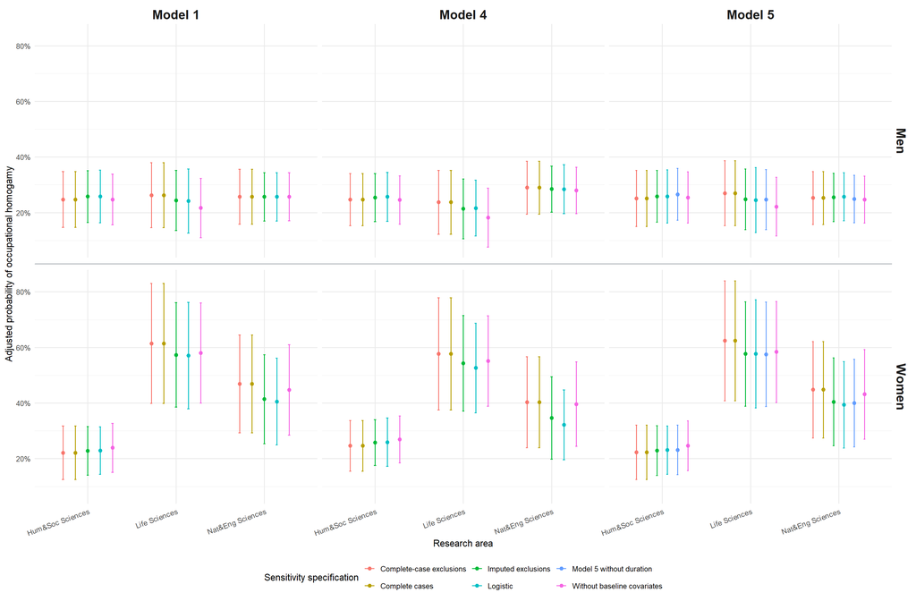

Only alternative specifications are plotted; primary Models 1, 4 and 5 probabilities remain in the main figures. Pointwise HC3/Rubin 95% CIs use each specification’s sample and covariate distribution.

### Figure S4. Continuous timing curves

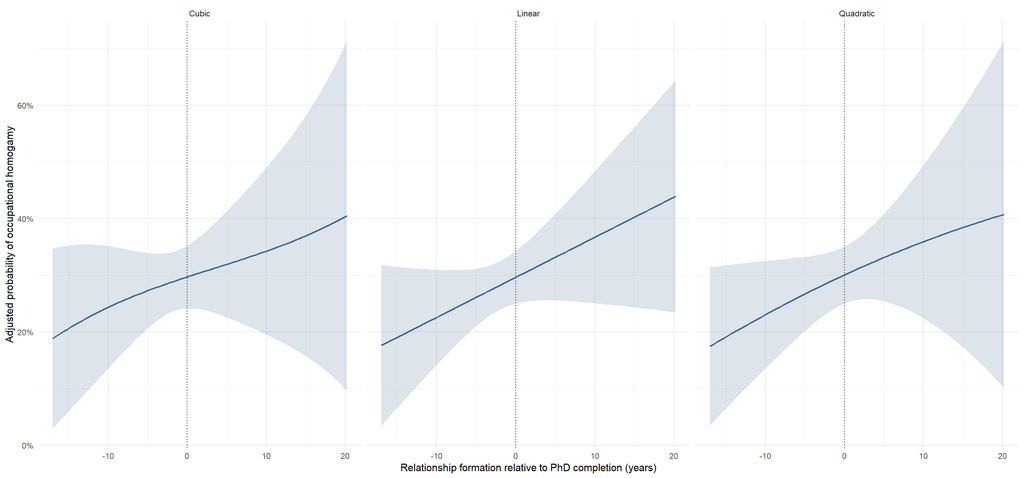

Primary linear, quadratic and cubic continuous-timing sensitivity curves with pointwise 95% CIs. Tests and other timing specifications are in Tables S3–S4.

### Figure S7. Logistic sensitivity: odds ratios

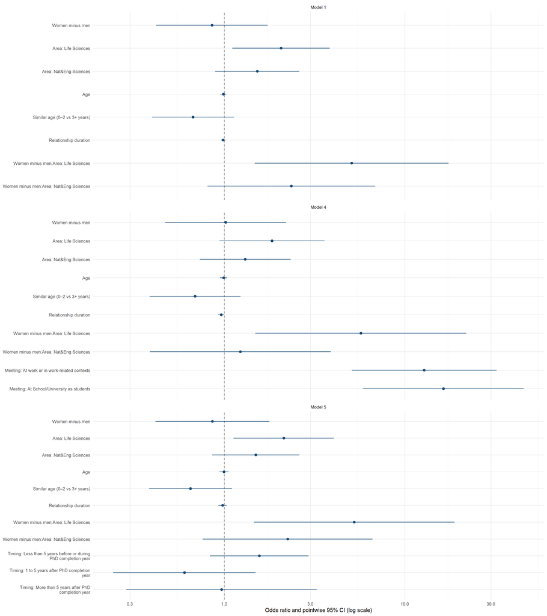

Logistic versions of occupational-homogamy Models 1, 4–5, with HC3/Rubin-pooled log-odds coefficients exponentiated to odds ratios. All non-intercept coefficients are shown without significance screening. The gender coefficient refers to Humanities & Social Sciences. Marginal probability contrasts and indirect associations are reported separately in Table S4.

## 4. Exploratory analyses: partner education and research similarity

### Table S5. Educational, topic and research-area similarity

| Type | Model | Term | Estimate [95% CI] | F | df1 | df2 | p | Adjustment | Generalized η² |
| --- | --- | --- | --- | --- | --- | --- | --- | --- | --- |
| Exploratory omnibus test | Topic (n = 118) | Gender | — | 0.07 | 1 | 105.64 | = .791 | Unadjusted | 0.001 |
| Exploratory omnibus test | Topic (n = 118) | Research area | — | 0.81 | 2 | 107.04 | = .446 | Unadjusted | 0.015 |
| Exploratory omnibus test | Topic (n = 118) | Interaction | — | 0.17 | 2 | 107.01 | = 1.000 | Holm across three outcomes | 0.003 |
| Exploratory within-area gender contrast | Topic | Women minus men: Hum&Soc Sciences | 4.3 [-27.5, 36.0] | — | — | — | = 1.000 | Holm across three areas | — |
| Exploratory within-area gender contrast | Topic | Women minus men: Life Sciences | -3.7 [-39.7, 32.2] | — | — | — | = 1.000 | Holm across three areas | — |
| Exploratory within-area gender contrast | Topic | Women minus men: Nat&Eng Sciences | -9.2 [-44.2, 25.8] | — | — | — | = 1.000 | Holm across three areas | — |
| Covariate omnibus p-value | Topic | age_c | — | — | — | — | = .382 | Unadjusted | — |
| Covariate omnibus p-value | Topic | age_homogamous_c | — | — | — | — | = .330 | Unadjusted | — |
| Covariate omnibus p-value | Topic | cp_duration_c | — | — | — | — | **= .031** | Unadjusted | — |
| Exploratory omnibus test | Area (n = 118) | Gender | — | 0.68 | 1 | 105.20 | = .412 | Unadjusted | 0.005 |
| Exploratory omnibus test | Area (n = 118) | Research area | — | 0.60 | 2 | 107.02 | = .551 | Unadjusted | 0.009 |
| Exploratory omnibus test | Area (n = 118) | Interaction | — | 1.38 | 2 | 107.00 | = .769 | Holm across three outcomes | 0.024 |
| Exploratory within-area gender contrast | Area | Women minus men: Hum&Soc Sciences | 2.4 [-19.3, 24.0] | — | — | — | = .955 | Holm across three areas | — |
| Exploratory within-area gender contrast | Area | Women minus men: Life Sciences | -10.4 [-39.2, 18.5] | — | — | — | = .955 | Holm across three areas | — |
| Exploratory within-area gender contrast | Area | Women minus men: Nat&Eng Sciences | 21.7 [-4.8, 48.1] | — | — | — | = .323 | Holm across three areas | — |
| Covariate omnibus p-value | Area | age_c | — | — | — | — | **= .016** | Unadjusted | — |
| Covariate omnibus p-value | Area | age_homogamous_c | — | — | — | — | = .380 | Unadjusted | — |
| Covariate omnibus p-value | Area | cp_duration_c | — | — | — | — | **= .013** | Unadjusted | — |
| Exploratory omnibus test | PhD (n = 292) | Gender | — | 1.18 | 1 | 280.53 | = .279 | Unadjusted | 0.004 |
| Exploratory omnibus test | PhD (n = 292) | Research area | — | **5.80** | **2** | **281.02** | **= .003** | Unadjusted | **0.043** |
| Exploratory omnibus test | PhD (n = 292) | Interaction | — | 0.12 | 2 | 281.01 | = 1.000 | Holm across three outcomes | 0.001 |
| Exploratory within-area gender contrast | PhD | Women minus men: Hum&Soc Sciences | 6.1 [-7.9, 20.0] | — | — | — | = 1.000 | Holm across three areas | — |
| Exploratory within-area gender contrast | PhD | Women minus men: Life Sciences | 1.9 [-31.4, 35.3] | — | — | — | = 1.000 | Holm across three areas | — |
| Exploratory within-area gender contrast | PhD | Women minus men: Nat&Eng Sciences | 11.6 [-13.9, 37.2] | — | — | — | = 1.000 | Holm across three areas | — |
| Covariate omnibus p-value | PhD | age_c | — | — | — | — | = .292 | Unadjusted | — |
| Covariate omnibus p-value | PhD | age_homogamous_c | — | — | — | — | = .596 | Unadjusted | — |
| Covariate omnibus p-value | PhD | cp_duration_c | — | — | — | — | = .616 | Unadjusted | — |
| Partner-education field contrast | PhD | Life Sciences minus Hum&Soc Sciences | 24.8 [7.1, 42.6] | — | — | — | **= .013** | Holm across two field comparisons | — |
| Partner-education field contrast | PhD | Nat&Eng Sciences minus Hum&Soc Sciences | 18.0 [3.7, 32.4] | — | — | — | **= .014** | Holm across two field comparisons | — |
| Exploratory extension omnibus test | Topic_Meeting | Gender | — | 0.25 | 1 | 103.41 | = .617 | Unadjusted supporting test | — |

[output cut: 185 more lines]

Education is analysed within non-academic couples; topic and area similarity within academic couples. Missing outcome responses and structural inapplicability are excluded. Adjusted probabilities appear in Figures 4–5; standardized baseline coefficient forest plots appear in Figure S5 and exploratory continuous-timing curves in Figure S6. Extension tests and standardized coefficients are supporting, unadjusted analyses. Covariates report p-values only. Generalized eta-squared is SS_effect / (SS_residual + sum of SS for all observed effects), excluding the intercept. Hypothesis sums of squares use ordinary least-squares model geometry with all predictors designated observed. Gender SS uses the reported sample-standardized marginal contrast; area SS uses equal-gender marginal contrasts; interaction and covariate SS use the reported coefficient blocks. Values are calculated within imputations and averaged descriptively, not Rubin-pooled, with no inferential CIs. HC3/Rubin F tests remain unchanged; generalized eta-squared is not obtained by converting those F statistics. Generalized eta-squared is reported for every estimable omnibus test, regardless of significance.

### Figure S5. Standardized coefficients for exploratory partner-similarity models

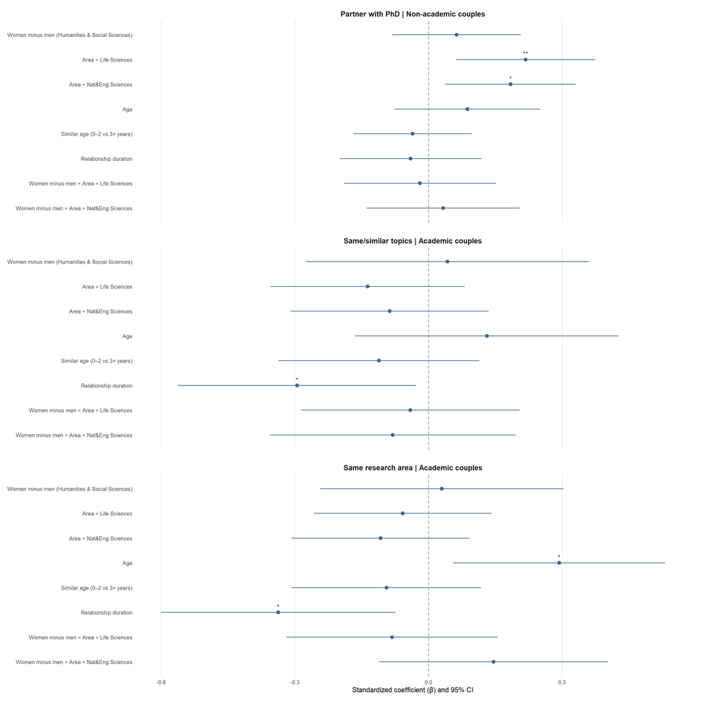

Exploratory baseline specifications include gender × research area, age, age similarity and relationship duration. Every non-intercept coefficient is shown, including covariates and interactions. Coefficients are standardized by SD(design column)/SD(outcome) within each imputation; scaled HC3 variances and estimates are then Rubin-pooled. Gender is the women–men coefficient in the reference field (Humanities & Social Sciences); field coefficients are at gender = 0 under effect coding. Interactions use their own design-column SDs. Pointwise 95% CIs and unadjusted coefficient tests: * p < .05; ** p < .01; *** p < .001. No significant-test screening is applied. Adjusted probabilities appear in main Figures 4–5.

### Figure S6. Continuous-timing sensitivity curves for exploratory similarity outcomes

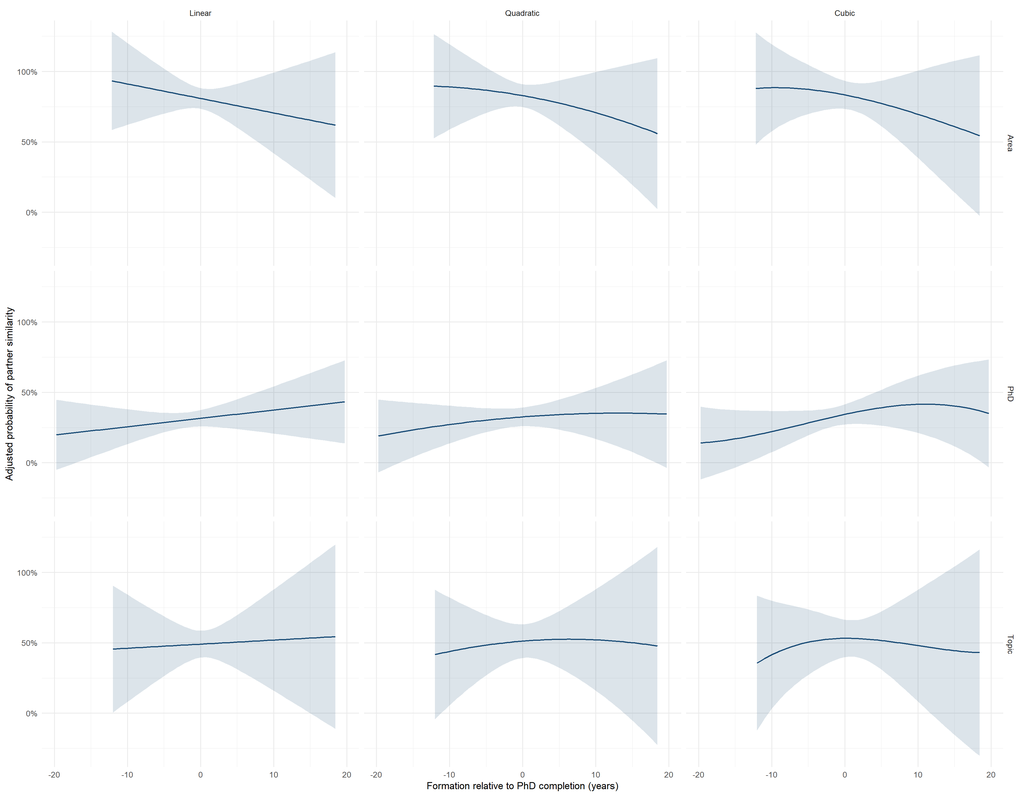

Separate linear, quadratic and cubic continuous-timing specifications for topic and area similarity in academic couples, and partner PhD status in non-academic couples. Models include gender × area and baseline covariates; curves cover the central 95% of timing values. Shading shows pointwise HC3/Rubin 95% CIs. Tests and coefficients are in Table S5.